# Three State Space Models Applied to One Time Series of Monarch Butterfly Abundance

Tim Meehan

2023-02-01

## Background

State space models (SSMs) are widely used in ecology. One common use is for modeling time series of population abundances. An advantage of using SSMs over other types of models is that they allow parsing the variation in the data into an observation portion and a process portion. The ability to parse out these two types of variation is useful in population studies because it allows for forecasts that ignore observation noise while incorporating biologically important process variation.

State space models can be specified and estimated in many ways. Here I demonstrate how to specify and estimate three commonly used SSMs in a Bayesian context using JAGS MCMC software interfaced with R statistical computing software. The three models used in the demonstration include a density independent Stochastic Level (SL) SSM, a density independent Stochastic Level with Drift (SD) SSM, and a density dependent Stochastic Gompertz (SG) SSM. For all three examples, the natural log of abundance, log(abundance) = $y_t$, is used as the response and error of log transformed aboundance is assumed to be normally distributed, which is common practice in the population ecology literature. All models assume that an observation at a given time, $y_t$, is an imperfect reflection of a true state, $x_t$. The noisy observation component for all three models is:

$$y_t = x_t + \epsilon_t
\quad\text{with}\quad \epsilon_t \sim N(0, \sigma^2_y),$$
where the observation at time $t$ depends on the true state at that time plus random observation error. The state component for the SL SSM is:
$$x_t = x_{t-1}
+ \eta_t \quad\text{with}\quad \eta_t \sim N(0, \sigma^2_x),$$
where the state at time $t$ depends on the state during the previous time step plus random process variation. The state component for the SD SSM is:
$$x_t = x_{t-1} + \beta_0 + \eta_t
\quad\text{with}\quad \eta_t \sim N(0, \sigma^2_x),$$
which is the same as the SL SSM except for the added assumption of average growth or drift, represented by $\beta_0$. The state component for the SG SSM is:
$$x_t
= x_{t-1} + \beta_0 + \beta_1(x_{t-1}) + \eta_t \quad\text{with}\quad
\eta_t \sim N(0, \sigma^2_x),$$
which is similar to the SD SSM except that $\beta_0$ is no longer a constant growth rate, but is analogous to a maximum growth rate that is modified by a density dependent growth rate penalty $\beta_1(x_{t-1})$.

The time series data used for this demonstration were gathered from the literature and comprise 29 years of total annual abundance estimates of monarch butterflies wintering in Mexico and along the West Coast of the USA. Each of the three SSMs is fitted to the monarch data, models are compared using information criteria, and 20-year forecasts are produced from each model and compared to five hypothetical quasi-extinction thresholds.

## Data

The demonstration starts by loading a bunch of R libraries and entering data gathered from the literature. The data are from two populations. They are combined here into one global population of migratory monarchs, for simplicity. There is a small bit of data tweaking to account for the fact that the much smaller Western population was not monitored from 1993 through 1996.

```r
# set up
library(kableExtra)
library(cowplot)
library(ggplot2)
library(arm)
library(loo)
library(MCMCvis)
library(R2jags)
library(dplyr)
setwd(getwd())

# write data
md0 <- data.frame(
  pop="Eastern migrants",
  year = 1993:2021,
  index = c(6.23, 7.81,12.61,18.19,5.77,5.56,8.97,2.83,9.36,7.54,11.12,
            2.19,5.91,6.87,4.61,5.06,1.92,4.02,2.89,1.19,0.67,1.13,4.01,
            2.91,2.48,6.05, 2.83, 2.10, 2.84)
) %>%
  mutate(index=round(index * 21100000,0)) %>%
  bind_rows(data.frame(
    pop="Western migrants",
    year = 1997:2021,
    index = c(1235490,564349,267574,390057,209570,99353,254378,205085,
              218679,221058,86437,131889,58468,143204,222525,144812,
              211275,234731,292888,298464,192624,27721,29436,1899,
              247246)))

# sum across regional populations
md1 <- md0 %>%
  group_by(year) %>%
  summarise(sites=n(),
            west_prop=min(index) / max(index),
            index=sum(index, na.rm=F))

# correct first four years using mean proportion from west
cf <- md1 %>% filter(west_prop!=1) %>% pull(west_prop) %>% mean() + 1
md1$index[md1$west_prop==1] <- md1$index[md1$west_prop==1] * cf
md1 <- md1 %>% dplyr::select(year, index) %>%
  mutate(yr=year-min(year)+1, log_idx=log(index))
```

## Stochastic level model

The first model, the SL SSM, is written out in JAGS syntax as follows. Note that the model statement includes prior specification, the model likelihood, and a derived parameter. Parsing out the two different types of variation in the data is both a benefit and a challenge of SSMs. It is common to make the job easier by setting an informed prior on the observation error when information is available. Luckily, this particular time series has been analyzed 1.3 gazillion times in the literature, so we can use previous observation error estimates to inform the prior. The derived parameter in the model statement is a point-wise log likelihood used for model evaluation. The value is not computed for the first time point because the initial state value is a guess. It is also not computed for 20 NA values added to the data for forecasting purposes. After writing out the model, I bundle the data for JAGS, specify some MCMC settings, and estimate the model. For more reproducible model results, increase ni, nt, and nb by a factor of 100 and wait an extra 40 minutes.

```r
# write model
cat(file = "ssm_mod.txt", "
model {
### priors
  mu[1] ~ dnorm(y[1], ((0.67-0.21)/1.97)^-2)
  tau.obs <- 1 / (sigma.obs * sigma.obs)
  sigma.obs ~ dnorm(0.44, ((0.67-0.21)/1.97)^-2)
  tau.proc <- 1 / (sigma.proc * sigma.proc)
  sigma.proc ~ dunif(0, 100)
### likelihood
  for (i in 2:n){
    y[i] ~ dnorm(mu[i], tau.obs)
    mu[i] ~ dnorm(mu[i - 1], tau.proc)
  }
### derived
  for(i in 2:29){
    loglik[i] <- logdensity.norm(y[i], mu[i], tau.obs)
  }
}
")

# data
y <- c(md1$log_idx, rep(NA, 20))
n <- length(y)
dat_ssm1 <- list(y = y, n = n); parameters <- c("loglik","mu","b0","b1","sigma.proc")

# mcmc settings
ni <- 150000; nt <- 10; nb <- 50000; nc <- 2; nad <- 10000

# call jags
stoch_out <- jags(dat_ssm1, inits=NULL, parameters, "ssm_mod.txt",
                 n.chains=nc, n.thin=nt, n.iter=ni, n.burnin=nb)
```

After running the model, I extract point-wise log likelihoods, produce the leave-one-out cross-validation information criterion (LOOIC) value for the model, and plot the data, model fit, and forecast.

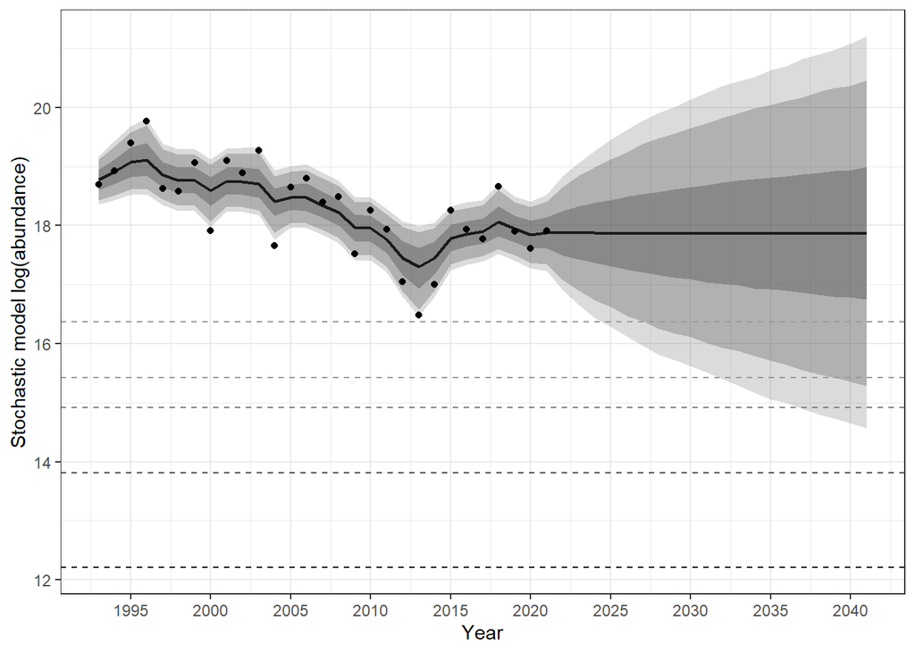

```r
# get logliks
stoch_ll <- stoch_out$BUGSoutput$sims.list$loglik
stoch_ref <- relative_eff(exp(stoch_ll), chain_id = rep(1:2, each = 10000))

# get looic
stoch_looic <- round(loo(stoch_ll, r_eff=stoch_ref)$estimates['looic','Estimate'], 2)

# compute fitted values
stoch_mus <- as.data.frame(MCMCsummary(stoch_out, "mu",
                                      probs=c(0.025, 0.05, 0.20, 0.5, 0.80,
                                              0.95, 0.975))[3:9]) %>%
  rename_with(~ paste0("stoch", gsub("%", "", .))) %>%
  mutate(year=1993:2041, log_idx=y)

# make ts plot
stoch_ts <- ggplot(stoch_mus, aes(x=year))  +
  geom_ribbon(aes(ymin=stoch2.5, ymax=stoch97.5), alpha=0.2, fill="gray30") +
  geom_ribbon(aes(ymin=stoch5, ymax=stoch95), alpha=0.3, fill="gray30") +
  geom_ribbon(aes(ymin=stoch20, ymax=stoch80), alpha=0.4, fill="gray30") +
  geom_line(aes(y=stoch50), linewidth=0.8, col="gray10") +
  geom_point(aes(y=log_idx), pch=16) +
  labs(x="Year", y="Stochastic model log(abundance)") +
  scale_y_continuous(limits=c()) +
  scale_x_continuous(breaks=seq(1995, 2040, 5)) +
  geom_hline(yintercept=log(200000), lty=2, col="gray10") +
  geom_hline(yintercept=log(1000000), lty=2, col="gray30") +
  geom_hline(yintercept=log(3000000), lty=2, col="gray50") +
  geom_hline(yintercept=log(5000000), lty=2, col="gray60") +
  geom_hline(yintercept=log(12800000), lty=2, col="gray60") +
  theme_bw()
stoch_ts
```

The plot shows $y_t$ as points and estimated $x_t$ as a solid line and gray ribbons. The solid line is the posterior median estimate of $x_t$ while the gray ribbons, from light to dark, show 95%, 90%, and 60% credible intervals, respectively. The horizontal lines highlight quasi-extinction abundances of 200,000 (bottom), 1 million, 3 million, 5 million, and 12.8 million (top).

The SL SSM does not have a drift or trend term in the state component, so the predicted state is a continuation of the state estimated at the time when observations ended. The uncertainty around predicted state values grows with time according to the estimated process variation, $\sigma^2_x$. It is possible to glean information about quasi-extinction probabilities from the plot, but we will save that discussion for later after we determine the best model for the data.

## Stochastic drift model

Next, I write the SD SSM model in JAGS syntax, estimate the model, compute LOOIC, and plot the data, model fit, and forecast.

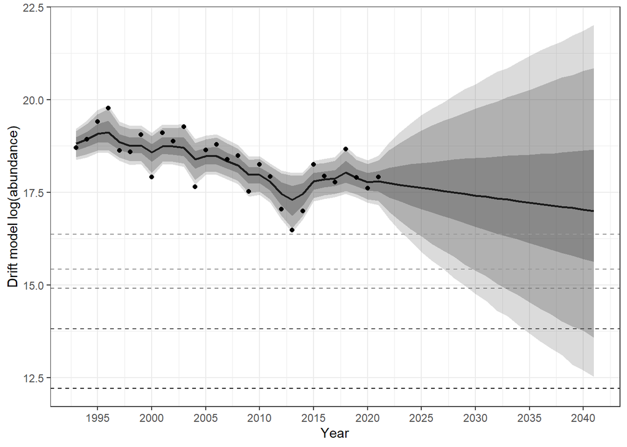

```r
cat(file = "ssm_mod.txt", "
model {
### priors
  mu[1] ~ dnorm(y[1], ((0.67-0.21)/1.97)^-2)
  b0 ~ dnorm(0, 0.001)
  tau.obs <- 1 / (sigma.obs * sigma.obs)
  sigma.obs ~ dnorm(0.44, ((0.67-0.21)/1.97)^-2)
  tau.proc <- 1 / (sigma.proc * sigma.proc)
  sigma.proc ~ dunif(0, 100)
### likelihood
  for (i in 2:n){
    y[i] ~ dnorm(mu[i], tau.obs)
    mu[i] ~ dnorm(mu[i - 1] + b0, tau.proc)
  }
### derived
  for(i in 2:29){
    loglik[i] <- logdensity.norm(y[i], mu[i], tau.obs)
  }
}
")

# call jags
drift_out <- jags(dat_ssm1, inits=NULL, parameters, "ssm_mod.txt",
                 n.chains=nc, n.thin=nt, n.iter=ni, n.burnin=nb)

# get logliks
drift_ll <- drift_out$BUGSoutput$sims.list$loglik
drift_ref <- relative_eff(exp(drift_ll), chain_id = rep(1:2, each = 10000))

# get looic
drift_looic <- round(loo(drift_ll, r_eff=drift_ref)$estimates['looic','Estimate'], 2)

# compute fitted values
drift_mus <- as.data.frame(MCMCsummary(drift_out, "mu",
                                      probs=c(0.025, 0.05, 0.20, 0.5, 0.80,
                                              0.95, 0.975))[3:9]) %>%
  rename_with(~ paste0("drift", gsub("%", "", .))) %>%
  mutate(year=1993:2041, log_idx=y)

# make ts plot
drift_ts <- ggplot(drift_mus, aes(x=year))  +
  geom_ribbon(aes(ymin=drift2.5, ymax=drift97.5), alpha=0.2, fill="gray30") +
  geom_ribbon(aes(ymin=drift5, ymax=drift95), alpha=0.3, fill="gray30") +
  geom_ribbon(aes(ymin=drift20, ymax=drift80), alpha=0.4, fill="gray30") +
  geom_line(aes(y=drift50), linewidth=0.8, col="gray10") +
  geom_point(aes(y=log_idx), pch=16) +
  labs(x="Year", y="Drift model log(abundance)") +
  scale_y_continuous(limits=c()) +
  scale_x_continuous(breaks=seq(1995, 2040, 5)) +
  geom_hline(yintercept=log(200000), lty=2, col="gray10") +
  geom_hline(yintercept=log(1000000), lty=2, col="gray30") +
  geom_hline(yintercept=log(3000000), lty=2, col="gray50") +
  geom_hline(yintercept=log(5000000), lty=2, col="gray60") +
  geom_hline(yintercept=log(12800000), lty=2, col="gray60") +
  theme_bw()
drift_ts
```

The SD SSM has a constant drift or trend term, $\beta_0$, in the state component. The estimated value for $\beta_0$ is -0.036. Given a constant trend, the SD SSM predicts that abundance will continue to decline, regardless of recent patterns of population growth. Uncertainty around predicted state values grows with time due to process variation, $\sigma^2_x$, and uncertainty in $\beta_0$, which is large as $\beta_0$ has 95% credible limits of -0.185 and 0.120.

## Stochastic Gompertz model

Finally, I write the SG SSM model in JAGS syntax, estimate the model, compute LOOIC, and plot the data, model fit, and forecast.

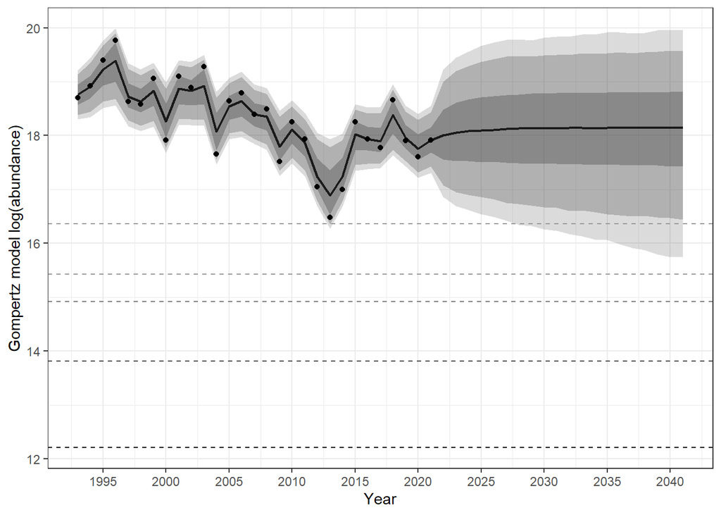

```r
cat(file = "ssm_mod.txt", "
model {
### priors
  mu[1] ~ dnorm(y[1], ((0.67-0.21)/1.97)^-2)
  b0 ~ dnorm(0, 0.001)
  b1 ~ dnorm(0, 0.001)
  tau.obs <- 1 / (sigma.obs * sigma.obs)
  sigma.obs ~ dnorm(0.44, ((0.67-0.21)/1.97)^-2)
  tau.proc <- 1 / (sigma.proc * sigma.proc)
  sigma.proc ~ dunif(0, 100)
### likelihood
  for (i in 2:n){
    y[i] ~ dnorm(mu[i], tau.obs)
    mu[i] ~ dnorm(mu[i - 1] + b0 + (b1 * mu[i - 1]), tau.proc)
  }
### derived
  for(i in 2:29){
    loglik[i] <- logdensity.norm(y[i], mu[i], tau.obs)
  }
}
")

# call jags
gomp_out <- jags(dat_ssm1, inits=NULL, parameters, "ssm_mod.txt",
                 n.chains=nc, n.thin=nt, n.iter=ni, n.burnin=nb)

# get logliks
gomp_ll <- gomp_out$BUGSoutput$sims.list$loglik
gomp_ref <- relative_eff(exp(gomp_ll), chain_id = rep(1:2, each = 10000))

# get looic
gomp_looic <- round(loo(gomp_ll, r_eff=gomp_ref)$estimates['looic','Estimate'], 2)

# compute fitted values
gomp_mus <- as.data.frame(MCMCsummary(gomp_out, "mu",
                                      probs=c(0.025, 0.05, 0.20, 0.5, 0.80,
                                              0.95, 0.975))[3:9]) %>%
  rename_with(~ paste0("gomp", gsub("%", "", .))) %>%
  mutate(year=1993:2041, log_idx=y)

# make ts plot
gomp_ts <- ggplot(gomp_mus, aes(x=year))  +
  geom_ribbon(aes(ymin=gomp2.5, ymax=gomp97.5), alpha=0.2, fill="gray30") +
  geom_ribbon(aes(ymin=gomp5, ymax=gomp95), alpha=0.3, fill="gray30") +
  geom_ribbon(aes(ymin=gomp20, ymax=gomp80), alpha=0.4, fill="gray30") +
  geom_line(aes(y=gomp50), linewidth=0.8, col="gray10") +
  geom_point(aes(y=log_idx), pch=16) +
  labs(x="Year", y="Gompertz model log(abundance)") +
  scale_y_continuous(limits=c()) +
  scale_x_continuous(breaks=seq(1995, 2040, 5)) +
  geom_hline(yintercept=log(200000), lty=2, col="gray10") +
  geom_hline(yintercept=log(1000000), lty=2, col="gray30") +
  geom_hline(yintercept=log(3000000), lty=2, col="gray50") +
  geom_hline(yintercept=log(5000000), lty=2, col="gray60") +
  geom_hline(yintercept=log(12800000), lty=2, col="gray60") +
  theme_bw()
gomp_ts
```

Like the SD SSM, the SG SSM also has growth explicitly included in the model. However, net growth in the SG SSM is not based on a single long term average, but rather depends on two terms, with one considering the previous state. In this way, the SG SSM has a mechanism for allowing growth rates to vary over time. The parameter estimate for $\beta_1$ from the SG SSM is approximately -0.31, suggesting negative density dependent growth. Forecasted values from the SG SSM level off at a population size of approximately exp(18.14) or 76 million monarchs, very close to the hypothetical stationary value of $exp(\beta_0 \div (1 - (\beta_1 + 1)))$ or roughly 80 million monarchs. Uncertainty around forecasted state values grows with time due to process variation, $\sigma^2_x$, and uncertainty in $\beta_0$ and $\beta_1$. Interestingly, uncertainty in future states appears less than that from the other two models. Why might this be?

## Compare models

Next, I pull together the LOOIC values from each model to compare predicted performance versus parsimony. Additionally, I use the point-wise likelihoods to compute model weights for each model.

```r
stack_wts <- loo_model_weights(x=list(gomp_mod=gomp_ll, drift_mod=drift_ll,
                                      stoch_mod=stoch_ll),
                               r_eff_list=list(gomp_ref, drift_ref, stoch_ref),
                               method = "stacking")

bma_wts <- loo_model_weights(x=list(gomp_mod=gomp_ll, drift_mod=drift_ll,
                                      stoch_mod=stoch_ll),
                               r_eff_list=list(gomp_ref, drift_ref, stoch_ref),
                               method = "pseudobma")

comp_tab <- data.frame(looic=c(gomp_looic, drift_looic, stoch_looic),
           stack_wts=round(c(stack_wts),2),
           bma_wts=round(c(bma_wts),2)) %>% arrange(looic)

kbl(comp_tab) %>% kable_styling()
```

|  | looic | stack_wts | bma_wts |
| --- | --- | --- | --- |
| gomp_mod | 45.96 | 1 | 0.84 |
| stoch_mod | 50.84 | 0 | 0.09 |
| drift_mod | 51.33 | 0 | 0.07 |

It is pretty clear from the LOOIC values and model weights that the SG SSM is the most appropriate of these three models for these data. The high model weights for the SG SSM suggest that density dependence is an important factor affecting annual abundance changes. The high LOOIC of the SD SSM suggests that models assuming constant density independent growth are not well suited to this time series.

It is common in the ecological literature to use an SG SSM to explore density dependence in species population dynamics. Another simple and intuitive method is to compute raw annual growth rates and plot and regress them against raw abundances during the previous time step to look for a relationship. This has been done previously by monarch researchers; I demonstrate how it is done because the results are fairly striking.

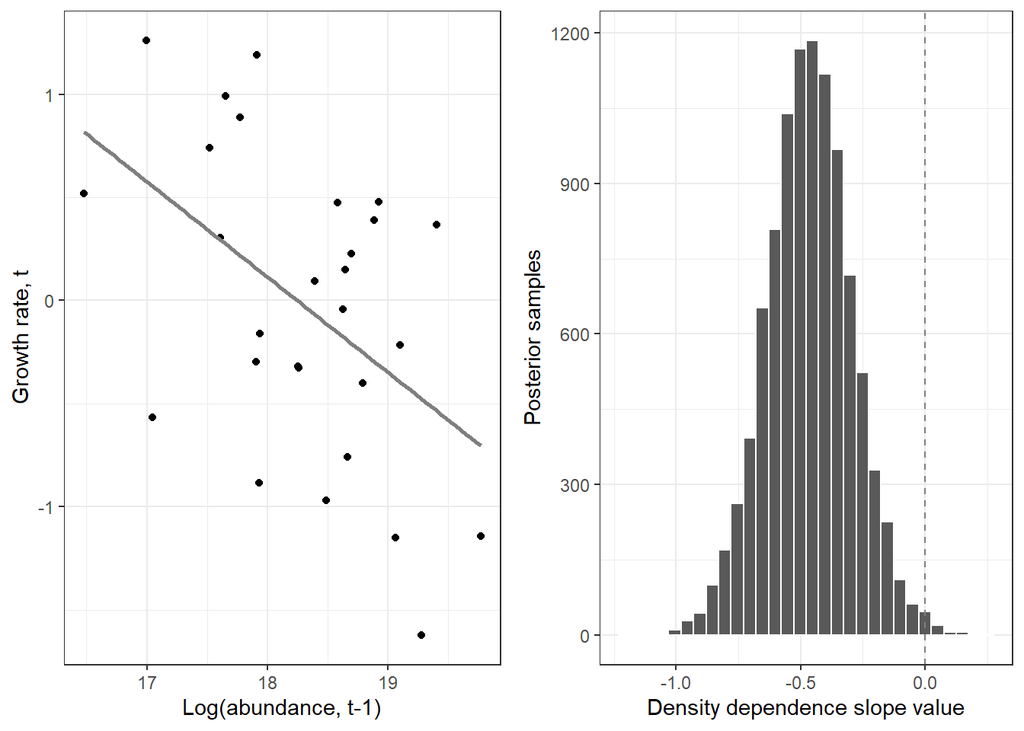

```r
# calculate raw growth rates at t
rt <- diff(md1$log_idx)

# get raw abundances at t-1
Ntm1 <- md1$log_idx[-29]

# plot growth rate at t versus abundance at t-1
dd_scatter <- ggplot(data.frame(rt=rt, Ntm1=Ntm1), aes(x=Ntm1, y=rt)) +
  geom_point() +
  labs(x="Log(abundance, t-1)", y="Growth rate, t") +
  geom_smooth(method="lm", col="gray50", se=F) +
  theme_bw()

# regress growth rate at t versus abundance at t-1
dd_mod <- lm(rt~Ntm1)

# get and plot the posterior distribution for the slope
dd_slope <- sim(dd_mod, 10000)@coef[,2]
dd_hist <- ggplot(data.frame(x=dd_slope), aes(x)) +
  geom_histogram(col="white") +
  geom_vline(xintercept=0, lty=2, col="gray50") +
  labs(y="Posterior samples", x="Density dependence slope value") +
  theme_bw()

# two plots together
plot_grid(dd_scatter, dd_hist)
```

This exercise produces a very clear picture of negative density dependence in monarch population growth rates, and emphasizes that a density dependent Gompertz state space model is the most appropriate of these three models for this time series.

## Model projections

We can use the posterior distribution of forecasted abundance in 2041 from the SG SSM to examine the probability that abundance falls below a variety of quasi-extinction thresholds.

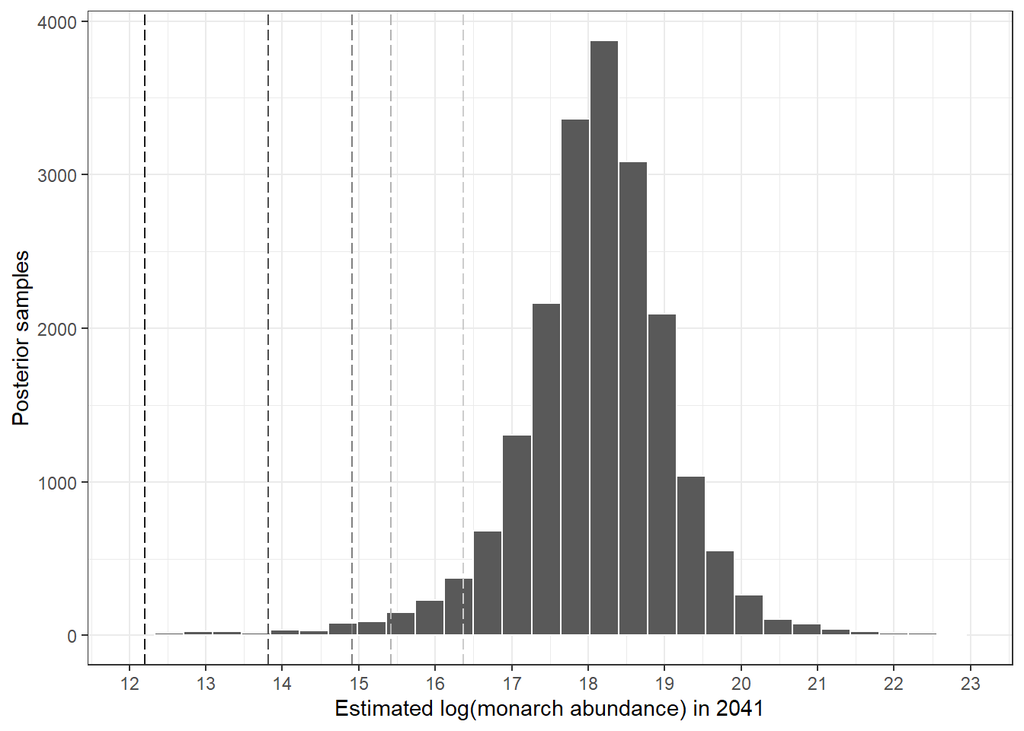

```r
# get draws for mu[49] year 2041
samps_49 <- as.numeric(MCMCchains(gomp_out, "mu[49]", ISB = F))

# get exceedence probabilities
p_200k <- sum(samps_49 < log(200000)) / length(samps_49)
p_1m <- sum(samps_49 < log(1000000)) / length(samps_49)
p_3m <- sum(samps_49 < log(3000000)) / length(samps_49)
p_5m <- sum(samps_49 < log(5000000)) / length(samps_49)
p_12m <- sum(samps_49 < log(12800000)) / length(samps_49)

# mu 49 histogram
hist_49 <- ggplot() +
  geom_histogram(data=data.frame(x=samps_49), aes(x=x),
               col="white") +
  labs(x="Estimated log(monarch abundance) in 2041", y="Posterior samples") +
  scale_x_continuous(limits=c(12, 23), breaks=seq(5, 30, 1)) +
  geom_vline(xintercept=log(200000), lty=5, col="gray10") +
  geom_vline(xintercept=log(1000000), lty=5, col="gray30") +
  geom_vline(xintercept=log(3000000), lty=5, col="gray50") +
  geom_vline(xintercept=log(5000000), lty=5, col="gray70") +
  geom_vline(xintercept=log(12800000), lty=5, col="gray80") +
  theme_bw()
hist_49
```